# HW 05: County Health

Model Comparison/Evaluation + Outliers

In this homework, you’ll use simple and multiple linear regression to analyze the relationship between the number of doctors in a county, the number of beds, and the number of hospitals.

# Learning goals

By the end of the homework you will be able to…

- compare models using $R^2$ and RMSE
- transform observations to improve model fit
- talk about outliers
- fit a model with two predictors

# Getting started

- Go to [RStudio](https://rstudio.collegeofidaho.edu) and login with your College of Idaho Email and Password.
- Make a subfolder in your `hw` directory to store this homework.
- Log into [Canvas](https://cofi.instructure.com/courses/17093/assignments/202863), navigate to Homework 5 and upload the `hw-05.qmd` file into the folder your just made.

# Packages

We’ll use the following packages in this homework.

```r
library(tidyverse)
library(broom)
library(yardstick)
library(ggformula)
library(knitr)
library(patchwork)
library(Stat2Data)
library(GGally)
# add more packages as needed
```

## Data: County Health

The data set for this homework is from the `Stat2Data` R package which is the companion package for this course’s textbook. It is the same data set that we used in AE-08. The data was originally generated by the American Medical Association and concerns the availability of health care in counties in the United States. You can find information [here](https://cran.r-project.org/web/packages/Stat2Data/Stat2Data.pdf) by searching for the County Health Resources dataset.

```r
data("CountyHealth") # Loads the data from the package
```

It is relatively easy to count the number of hospitals a county has, whereas counting the number of doctors is much more difficult. We’d like to build a linear model to predict the number of doctors, contained in the variable `MDs`, from the number of hospitals, `Hospitals` and the number of beds, `Beds`.

## Exercise 1

Describe was an observational unit represents for this data set. How many are there?

For this data set, observational units represent different counties in America and there are 53 of them.

```r
summary(CountyHealth)
```

```
                                  County        MDs         Hospitals
 Bay, FL                             : 1   Min.   :   5   Min.   : 2.000
 Beaufort, NC                        : 1   1st Qu.:  56   1st Qu.: 2.000
 Beaver, PA                          : 1   Median : 260   Median : 2.000
 Bernalillo, NM                      : 1   Mean   :1088   Mean   : 3.962
 Bibb, GA                            : 1   3rd Qu.:1145   3rd Qu.: 5.000
 Clinton, PA                         : 1   Max.   :8908   Max.   :13.000
 (Other)                             :47
      Beds
 Min.   :  33.0
 1st Qu.: 145.0
 Median : 350.0
 Mean   : 868.8
 3rd Qu.:1389.0
 Max.   :5034.0
```

```r
nrow(CountyHealth)
```

```
[1] 53
```

## Exercise 2

In Example 1.7 of Stat2, they consider a simple linear model to predict the number of doctors (`MDs`) from the number of hospitals (`Hospitals`) in a metropolitan area. In that example, they found that a square root transformation on the response variable produced a more linear relationship. Create a new variable in the `CountyHealth` data frame called `sqrtMDs`. Hint: use the `sqrt` function inside the `mutate` function.

```r
CountyHealth <- CountyHealth |>
  mutate(sqrtMDs = sqrt(MDs))

CountyHealth
```

```
                                 County  MDs Hospitals Beds   sqrtMDs
1  Bay, FL                               351         3  605 18.734994
2  Beaufort, NC                           95         2  134  9.746794
3  Beaver, PA                            260         2  567 16.124515
4  Bernalillo, NM                       2797        11 1435 52.886671
5  Bibb, GA                              769         5  976 27.730849
6  Clinton, PA                            42         2  245  6.480741
7  Comanche, TX                           13         2   33  3.605551
8  Concordia, LA                          20         2   65  4.472136
9  Contra Costa, CA                     2981         7 1462 54.598535
10 Coos, NH                               83         3  100  9.110434
11 Crawford, KS                           56         2  179  7.483315
12 Creek, OK                              37         2   42  6.082763
13 Dona Ana, NM                          320         2  350 17.888544
14 Douglas, OR                           224         2  202 14.966630
```

[output cut: 39 more lines]

## Exercise 3

Use the function `ggpairs` from the package `GGally` to generate a grid scatter plots and correlations. Note that you will need to select the variables you want to use. Which explanatory variable (`Hospitals` or `Beds`) has the highest correlation with `SqrtMDs`? Is this consistent with your visual assessment?

Beds has the highest correlation with SqrtMDs.

Yes, we can see visually as well. the scatter plot with Beds seems to be have stronger relationship that with Hospitals.

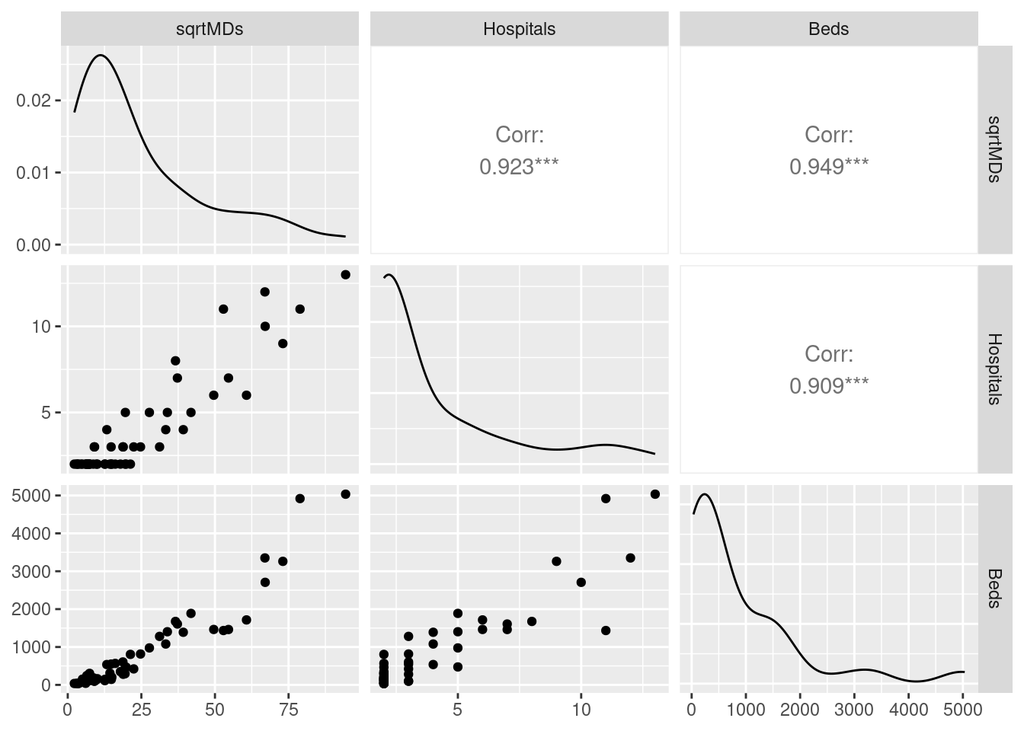

```r
ggpairs(CountyHealth, columns = c("sqrtMDs", "Hospitals", "Beds"))
```

## Exercise 4

Fit a simple linear model using `SqrtMDs` as the response variable and `Hospitals` as the predictor. You may use `sqrt(MDs)` in your `lm` call instead of `SqrtMDs` if you like. How much of the variability in the `SqrtMDs` values is explained by `Hospitals`? How much of the variability in `MDs` is explained by the model you just fit. To figure this out:

1. Augment your model.

   ```r
   model_hospitals <- lm(sqrt(MDs) ~ Hospitals, data = CountyHealth)
   augment <- augment(model_hospitals)
   augment
   ```

   ```
   # A tibble: 53 × 8
      `sqrt(MDs)` Hospitals .fitted  .resid   .hat .sigma  .cooksd .std.resid
            <dbl>     <int>   <dbl>   <dbl>  <dbl>  <dbl>    <dbl>      <dbl>
    1       18.7          3    17.9   0.859 0.0209   8.74 0.000107      0.100
    2        9.75         2    11.0  -1.25  0.0271   8.74 0.000300     -0.147
    3       16.1          2    11.0   5.13  0.0271   8.71 0.00502       0.600
    4       52.9         11    72.9 -20.0   0.125    8.20 0.436        -2.47
    5       27.7          5    31.6  -3.90  0.0212   8.73 0.00224      -0.455
    6        6.48         2    11.0  -4.52  0.0271   8.72 0.00390      -0.529
    7        3.61         2    11.0  -7.39  0.0271   8.68 0.0105       -0.866
    8        4.47         2    11.0  -6.53  0.0271   8.69 0.00815      -0.764
    9       54.6          7    45.4   9.22  0.0387   8.64 0.0237        1.09
   10        9.11         3    17.9  -8.77  0.0209   8.65 0.0111       -1.02
   # ℹ 43 more rows
   ```

2. Convert the fitted and observed response variables back to number of MDs rather than square-root of the number of MDs.

   ```r
   augment <- augment |>
     mutate(
       fitted_values = .fitted^2,
       observed_values = `sqrt(MDs)`^2
      )

   augment
   ```

   ```
   # A tibble: 53 × 10
      `sqrt(MDs)` Hospitals .fitted  .resid   .hat .sigma  .cooksd .std.resid
            <dbl>     <int>   <dbl>   <dbl>  <dbl>  <dbl>    <dbl>      <dbl>
    1       18.7          3    17.9   0.859 0.0209   8.74 0.000107      0.100
    2        9.75         2    11.0  -1.25  0.0271   8.74 0.000300     -0.147
    3       16.1          2    11.0   5.13  0.0271   8.71 0.00502       0.600
    4       52.9         11    72.9 -20.0   0.125    8.20 0.436        -2.47
    5       27.7          5    31.6  -3.90  0.0212   8.73 0.00224      -0.455
    6        6.48         2    11.0  -4.52  0.0271   8.72 0.00390      -0.529
    7        3.61         2    11.0  -7.39  0.0271   8.68 0.0105       -0.866
    8        4.47         2    11.0  -6.53  0.0271   8.69 0.00815      -0.764
    9       54.6          7    45.4   9.22  0.0387   8.64 0.0237        1.09
   10        9.11         3    17.9  -8.77  0.0209   8.65 0.0111       -1.02
   # ℹ 43 more rows
   # ℹ 2 more variables: fitted_values <dbl>, observed_values <dbl>
   ```

   ```r
   #my code was not workling so i used chatgpt and it gave me `sqrt(MDs)` which then worked. i was just using sqrt(MDs) first.
   ```

3. Compute the $R^2$.

   ```r
   rsq(data=augment, truth = `sqrt(MDs)`,estimate=.fitted)
   ```

   ```
   # A tibble: 1 × 3
     .metric .estimator .estimate
     <chr>   <chr>          <dbl>
   1 rsq     standard       0.852
   ```

Why are these two numbers different?

## Exercise 5

Do you think taking the square root of `Beds` would improve this model? Support your argument with plots and/or numbers.

Looking at the two graphs, one with sqrtBeds and the other with Hospital, we can clearly see the difference. sqrtBeds shows a clear linear relationship with points distributed along the straight line. but with Hospitals, it is not the same. there is a positive trend but there is more spread and are not that clustered along the straight line.

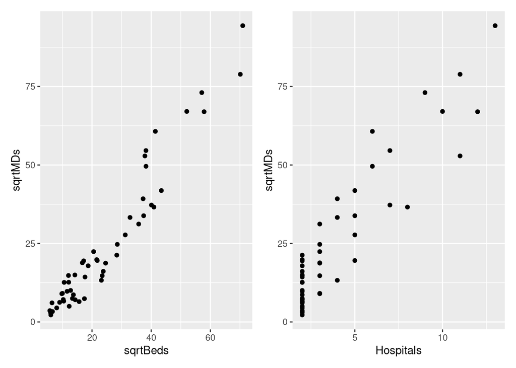

```r
CountyHealth <- CountyHealth |>
  mutate(sqrtBeds = sqrt(Beds))

p1 <- gf_point(sqrtMDs ~ sqrtBeds, data = CountyHealth)
p2 <- gf_point(sqrtMDs ~ Hospitals, data = CountyHealth)
p1 + p2
```

## Exercise 6

Repeat exercise 4 above with `Beds` as the predictor instead of `Hospitals`.

```r
model_beds <- lm(sqrt(MDs) ~ Beds, data = CountyHealth)
augment2 <- augment(model_beds)
augment2
```

```
# A tibble: 53 × 8
   `sqrt(MDs)`  Beds .fitted .resid   .hat .sigma  .cooksd .std.resid
         <dbl> <int>   <dbl>  <dbl>  <dbl>  <dbl>    <dbl>      <dbl>
 1       18.7    605   19.6  -0.900 0.0199   7.15 0.000167     -0.128
 2        9.75   134   11.0  -1.21  0.0267   7.15 0.000414     -0.174
 3       16.1    567   18.9  -2.81  0.0202   7.14 0.00166      -0.401
 4       52.9   1435   34.9  18.0   0.0235   6.68 0.0794        2.57
 5       27.7    976   26.5   1.26  0.0190   7.15 0.000314      0.180
 6        6.48   245   13.0  -6.52  0.0245   7.09 0.0109       -0.932
 7        3.61    33    9.10 -5.50  0.0290   7.11 0.00927      -0.787
 8        4.47    65    9.69 -5.22  0.0283   7.12 0.00812      -0.747
 9       54.6   1462   35.4  19.2   0.0240   6.61 0.0923        2.74
10        9.11   100   10.3  -1.22  0.0275   7.15 0.000434     -0.175
# ℹ 43 more rows
```

```r
augment2 <- augment2 |>
  mutate(
    fitted_values = .fitted^2,
    observed_values = `sqrt(MDs)`^2
   )

augment2
```

```
# A tibble: 53 × 10
   `sqrt(MDs)`  Beds .fitted .resid   .hat .sigma  .cooksd .std.resid
         <dbl> <int>   <dbl>  <dbl>  <dbl>  <dbl>    <dbl>      <dbl>
 1       18.7    605   19.6  -0.900 0.0199   7.15 0.000167     -0.128
 2        9.75   134   11.0  -1.21  0.0267   7.15 0.000414     -0.174
 3       16.1    567   18.9  -2.81  0.0202   7.14 0.00166      -0.401
 4       52.9   1435   34.9  18.0   0.0235   6.68 0.0794        2.57
 5       27.7    976   26.5   1.26  0.0190   7.15 0.000314      0.180
 6        6.48   245   13.0  -6.52  0.0245   7.09 0.0109       -0.932
 7        3.61    33    9.10 -5.50  0.0290   7.11 0.00927      -0.787
 8        4.47    65    9.69 -5.22  0.0283   7.12 0.00812      -0.747
 9       54.6   1462   35.4  19.2   0.0240   6.61 0.0923        2.74
10        9.11   100   10.3  -1.22  0.0275   7.15 0.000434     -0.175
# ℹ 43 more rows
# ℹ 2 more variables: fitted_values <dbl>, observed_values <dbl>
```

```r
rsq(data=augment2, truth = `sqrt(MDs)`,estimate=.fitted)
```

```
# A tibble: 1 × 3
  .metric .estimator .estimate
  <chr>   <chr>          <dbl>
1 rsq     standard       0.901
```

## Exercise 7

For the model you just fit, are there any high-influence outliers? Justify your answer using something from the lecture on outliers. There appear to be at least two high-leverage points. Which observations are these?

There are three that i found. One of them was ~3000 and the others were about ~5000. There are two types of outliers. They are high leverage and high influence. The points around 5000 are high influence they impact the regression line but the point at around 3000 could be considered high leverage because it might influence it a little but don’t have a major impact.

## Exercise 8

Fit a multiple linear model using `SqrtMDs` as the response variable and both `Hospitals` and `Beds` as the predictors. Interpret both slopes and the intercept in the context of the problem.

```r
model <- lm(sqrt(MDs) ~ Hospitals + Beds, data = CountyHealth)
model
```

```
Call:
lm(formula = sqrt(MDs) ~ Hospitals + Beds, data = CountyHealth)

Coefficients:
(Intercept)    Hospitals         Beds
    3.58081      2.57935      0.01231
```

For Hospitals: For every unit increase in Hospitals, the square root of MDs increases by about 2.58 units, keeping Beds constant.

For Beds: For every unit increase in Beds, the square root of MDs increases by about 0.012 units, keeping Hospitals constant.

## Exercise 9

How much of the variation in `MDs` is explained by the model you just fit? Which model would you say is the “best”, given what we’ve learned through the first lecture on multiple linear regression.

```r
rsq(data=augment(model_hospitals), truth = `sqrt(MDs)`,estimate=.fitted)
```

```
# A tibble: 1 × 3
  .metric .estimator .estimate
  <chr>   <chr>          <dbl>
1 rsq     standard       0.852
```

```r
rsq(data=augment(model_beds), truth = `sqrt(MDs)`,estimate=.fitted)
```

```
# A tibble: 1 × 3
  .metric .estimator .estimate
  <chr>   <chr>          <dbl>
1 rsq     standard       0.901
```

```r
rsq(data = augment(model), truth = `sqrt(MDs)`, estimate = .fitted)
```

```
# A tibble: 1 × 3
  .metric .estimator .estimate
  <chr>   <chr>          <dbl>
1 rsq     standard       0.922
```

By this fit, 92.17% variations has been shown. I would say this one is better because it has captured more variation than the one with model_hospitals. And also in this one, we can also see how both Bed and Hospitals have contributed to response variable but in model_hospitals, we can only see how Hospitals have contributed to response variable.

## Exercise 10

Using the “best” model, predict the average number of doctors in a metro area with 1,000 beds and 4 hospitals. Report a 95% prediction interval and interpret your results in context.

```r
predict(model, newdata = (tibble(Hospitals = 4, Beds = 1000)), interval = "prediction", level = 0.95)
```

```
       fit      lwr      upr
1 26.20521 13.29991 39.11052
```

## Grading

Total points available: 20 points.

| Component | Points |
| --- | --- |
| Ex 1 | 1 |
| Ex 2 | 1 |
| Ex 3 | 2 |
| Ex 4 | 2 |
| Ex 5 | 2 |
| Ex 6 | 2 |
| Ex 7 | 2 |
| Ex 8 | 2 |
| Ex 9 | 2 |
| Ex 10 | 2 |
| Grammar & Writing | 1[^1] |
| Workflow & formatting | 1[^2] |

## Footnotes

[^1]: The “Grammar & Writing” grade is decided based on your grammar and writing. This is typically decided by choosing one of the questions and assessing the writing.
[^2]: The “Workflow & formatting” grade is to assess the reproducible workflow and document format. This includes having a neatly organized document with readable code and your name and the date in the YAML.